# Counterfactuals

```r
library(feather)
library(survey)
options(survey.lonely.psu="adjust",multicore=TRUE)
library(tidycensus)
library(tidyverse)
library(ggplot2)
library(dplyr)
library(texreg)
library(cdlTools)
library(kableExtra)
library(ciTools)
library(sandwich)
library(lmtest)
library(fst)
```

```r
tripsTMPS=readRDS("tripsTMPS.rds")
tripsTMPS %>% head()
```

|  | Year | Month | Mode | Obs | Trips | Hrsf | Party | Miles | Htvl | FIPS | State | Population | Stringency | TPC |
| --- | --- | --- | --- | --- | --- | --- | --- | --- | --- | --- | --- | --- | --- | --- |
| 1 | 2017 | 01 | 3 | 16 | 248979.7 | 2.020346 | NaN | 16.80868 | 0.5824800 | 01 | Alabama | 4874747 | 0 | 0.05107541 |
| 2 | 2017 | 01 | 5 | 1 | 0.0 | NaN | NaN | NaN | NaN | 01 | Alabama | 4874747 | 0 | 0.00000000 |
| 3 | 2017 | 01 | 7 | 24 | 62044.6 | 3.406213 | 2.077482 | 24.67458 | 0.6903076 | 01 | Alabama | 4874747 | 0 | 0.01272776 |
| 4 | 2017 | 01 | 5 | 1 | 0.0 | NaN | NaN | NaN | NaN | 09 | Connecticut | 3588184 | 0 | 0.00000000 |
| 5 | 2017 | 01 | 3 | 1 | 0.0 | NaN | NaN | NaN | NaN | 09 | Connecticut | 3588184 | 0 | 0.00000000 |
| 6 | 2017 | 01 | 7 | 1 | 0.0 | NaN | NaN | NaN | NaN | 09 | Connecticut | 3588184 | 0 | 0.00000000 |

Estimate model for private mode:

```r
mf=formula(Trips ~ State + Month + I(Stringency/100) + I((Stringency/100)^2) + log(Population))
pm=glm(mf,data=tripsTMPS,family = quasipoisson,subset=Mode==7 )
```

How do the actual trip values compare with model-predicted values?

```r
private_trips_predictions <- tripsTMPS %>%
  filter(Mode == "7") %>%
  select(Year, Month, State, Population, Stringency, Trips) %>%
  add_ci(pm) %>%
  rename(Trips_hat = pred) %>%
  mutate(residuals = Trips - Trips_hat)

private_trips_predictions
```

| Year | Month | State | Population | Stringency | Trips | Trips_hat | LCB0.025 | UCB0.975 | residuals |
| --- | --- | --- | --- | --- | --- | --- | --- | --- | --- |
| 2017 | 01 | Alabama | 4874747 | 0.00 | 62044.5981 | 55330.793 | 42171.128 | 72596.98 | 6.713805e+03 |
| 2017 | 01 | Connecticut | 3588184 | 0.00 | 0.0000 | 40080.951 | 29830.207 | 53854.22 | -4.008095e+04 |
| 2017 | 01 | Delaware | 961939 | 0.00 | 0.0000 | 15280.101 | 10059.572 | 23209.88 | -1.528010e+04 |
| 2017 | 01 | Florida | 20984400 | 0.00 | 1300525.8362 | 851377.700 | 695235.699 | 1042587.41 | 4.491481e+05 |
| 2017 | 01 | Georgia | 10429379 | 0.00 | 0.0000 | 47665.904 | 35842.023 | 63390.35 | -4.766590e+04 |
| 2017 | 01 | Maine | 1335907 | 0.00 | 0.0000 | 15615.225 | 10292.200 | 23691.27 | -1.561522e+04 |
| 2017 | 01 | Maryland | 6052177 | 0.00 | 0.0000 | 76616.247 | 59704.697 | 98318.05 | -7.661625e+04 |
| 2017 | 01 | Massachusetts | 6859819 | 0.00 | 0.0000 | 76047.404 | 59145.247 | 97779.75 | -7.604740e+04 |
| 2017 | 01 | Mississippi | 2984100 | 0.00 | 73740.5080 | 43684.010 | 32782.410 | 58210.88 | 3.005650e+04 |
| 2017 | 01 | New Hampshire | 1342795 | 0.00 | 0.0000 | 8603.138 | 5072.272 | 14591.88 | -8.603138e+03 |

[output cut: 758 more lines]

This is a bit troubling, as we can immediately see there are some strange things going on with months that have “0 trips”…

How does a scatter plot look?

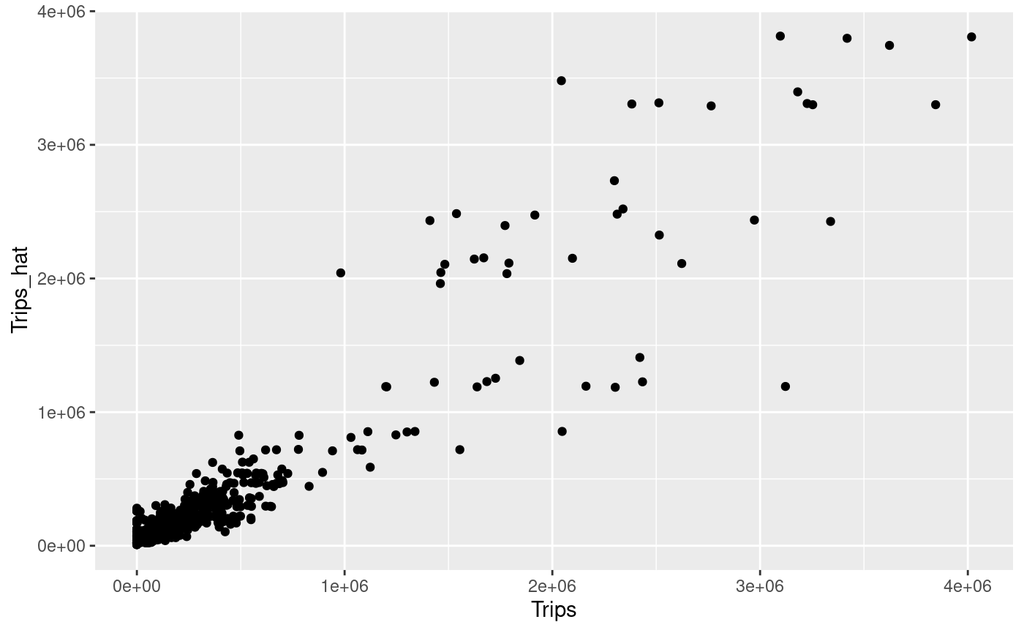

```r
private_trips_predictions %>%
  ggplot(aes(Trips, Trips_hat)) +
  geom_point()
```

Plotting the residuals:

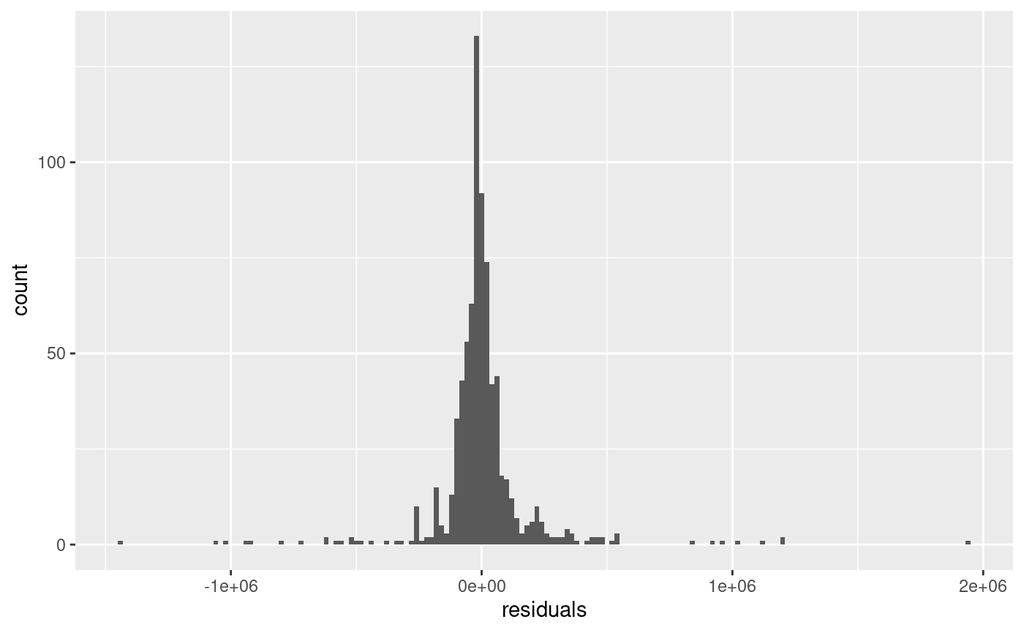

```r
private_trips_predictions %>%
  ggplot(aes(x = residuals)) +
  geom_histogram(binwidth=20000)
```

Print the model fit info:

```r
pm
```

```
Call:  glm(formula = mf, family = quasipoisson, data = tripsTMPS, subset = Mode ==
    7)

Coefficients:
          (Intercept)       StateConnecticut          StateDelaware           StateFlorida           StateGeorgia
             8.094017              -0.266175              -0.988850               2.465551              -0.288737
           StateMaine          StateMaryland     StateMassachusetts       StateMississippi     StateNew Hampshire
            -1.027446               0.285762               0.255314              -0.146251              -1.624509
      StateNew Jersey          StateNew York    StateNorth Carolina      StateRhode Island    StateSouth Carolina
             0.680299               0.954464               0.789628              -0.856949               0.270299
        StateVirginia                Month02                Month03                Month04                Month05
             0.116040               0.333729               0.362351               0.905716               1.047439
              Month06                Month07                Month08                Month09                Month10
             1.354865               1.495193               1.352204               1.066953               0.924104
              Month11                Month12      I(Stringency/100)  I((Stringency/100)^2)        log(Population)
             0.871929               0.331290               0.028610              -0.001294               0.183581

Degrees of Freedom: 767 Total (i.e. Null);  738 Residual
Null Deviance:      447600000
Residual Deviance: 55870000     AIC: NA
```

Lets look at the first scatter plot with logs:

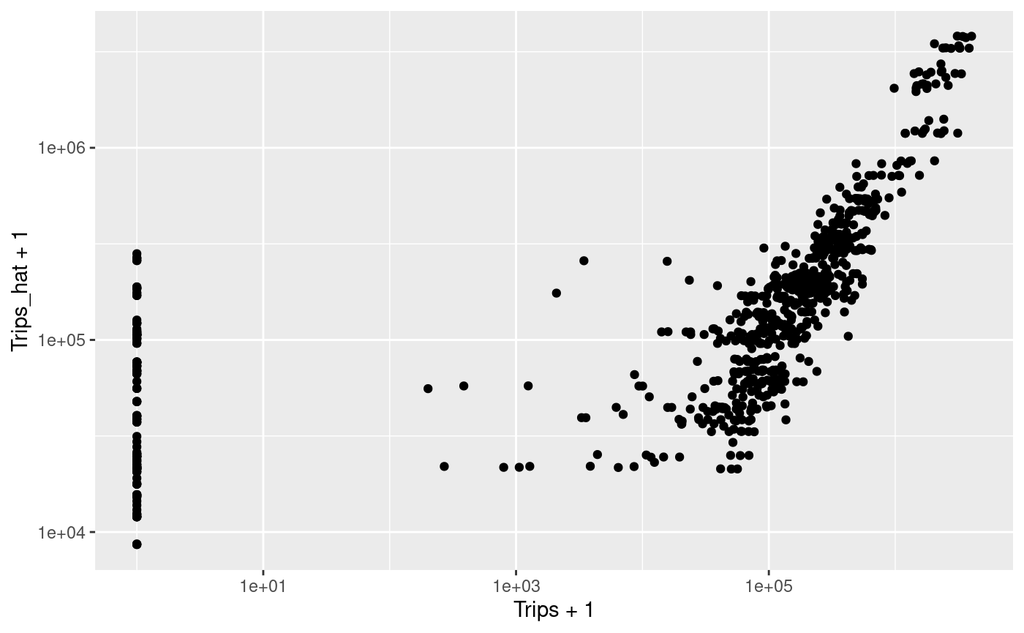

```r
private_trips_predictions %>%
  ggplot(aes(Trips+1, Trips_hat+1), ) +
  geom_point() +
  scale_x_log10() + scale_y_log10()
```

This shows much more clearly that we have a model which is producing reasonable predictions for most observations, but is drastically malfunctioning (specifically, overpredicting) for some observations, namely those which have “0” trips. This is because we estimate an overall national seasonality trend, not a state-specific seasonality trend.

Lets re-estimate the model excluding state-months for which there is no real data.

We first need to identify those state months:

```r
tripsTMPS %>%
  filter(Mode == "7") %>%
  group_by(State, Month) %>%
  summarise(max_Trips = max(Trips), .groups = "drop") %>%
  arrange(max_Trips)
```

| State | Month | max_Trips |
| --- | --- | --- |
| Connecticut | 01 | 0.000 |
| Connecticut | 02 | 0.000 |
| Delaware | 01 | 0.000 |
| Delaware | 02 | 0.000 |
| Georgia | 01 | 0.000 |
| Georgia | 02 | 0.000 |
| Maine | 01 | 0.000 |
| Maine | 02 | 0.000 |
| Maine | 03 | 0.000 |
| Maine | 04 | 0.000 |

[output cut: 182 more lines]

We have a total of 35 state-months which have 0 trips for all years. Lets get a list of these, compare them with the MRIP data collection guide, and remove them from the model:

```r
no_data_sms<- tripsTMPS %>%
  filter(Mode == "7") %>%
  group_by(State, Month) %>%
  summarise(max_Trips = max(Trips), .groups = "drop") %>%
  filter(max_Trips == 0) %>%
  select(State, Month)

no_data_sms
```

| State | Month |
| --- | --- |
| Connecticut | 01 |
| Connecticut | 02 |
| Delaware | 01 |
| Delaware | 02 |
| Georgia | 01 |
| Georgia | 02 |
| Maine | 01 |
| Maine | 02 |
| Maine | 03 |
| Maine | 04 |

[output cut: 25 more lines]

This all looks right, and lines up with figure 6 [here](https://media.fisheries.noaa.gov/2021-09/MRIP-Survey-Design-and-Statistical-Methods-2021-09-15.pdf).

```r
data_for_new_model <- tripsTMPS %>%
  filter(Mode == "7") %>%
  anti_join(no_data_sms, by = c("State", "Month"))

pm_new = glm(mf,data=data_for_new_model,family = quasipoisson)
pm_new
```

```
Call:  glm(formula = mf, family = quasipoisson, data = data_for_new_model)

Coefficients:
          (Intercept)       StateConnecticut          StateDelaware           StateFlorida           StateGeorgia
             8.859920              -0.124833              -0.869134               2.491556              -0.133114
           StateMaine          StateMaryland     StateMassachusetts       StateMississippi     StateNew Hampshire
            -0.560259               0.433762               0.461902              -0.152722              -1.178365
      StateNew Jersey          StateNew York    StateNorth Carolina      StateRhode Island    StateSouth Carolina
             0.833585               1.126318               0.804614              -0.621163               0.411451
        StateVirginia                Month02                Month03                Month04                Month05
             0.266560               0.333045              -0.154593               0.339163               0.461083
              Month06                Month07                Month08                Month09                Month10
             0.763599               0.903720               0.759226               0.471729               0.327560
              Month11                Month12      I(Stringency/100)  I((Stringency/100)^2)        log(Population)
             0.295040              -0.232646               0.034428              -0.001575               0.167590

Degrees of Freedom: 627 Total (i.e. Null);  598 Residual
Null Deviance:      355900000
Residual Deviance: 32740000     AIC: NA
```

Lets look at the residual plots for this new, reduced dataset and fitted model:

```r
private_trips_predictions_new <- data_for_new_model %>%
  select(Year, Month, State, Population, Stringency, Trips) %>%
  add_ci(pm_new) %>%
  rename(Trips_hat = pred) %>%
  mutate(residuals = Trips - Trips_hat)

private_trips_predictions_new
```

| Year | Month | State | Population | Stringency | Trips | Trips_hat | LCB0.025 | UCB0.975 | residuals |
| --- | --- | --- | --- | --- | --- | --- | --- | --- | --- |
| 2017 | 01 | Alabama | 4874747 | 0.00 | 62044.5981 | 93034.93 | 73312.38 | 118063.26 | -30990.3363 |
| 2017 | 01 | Florida | 20984400 | 0.00 | 1300525.8362 | 1435349.99 | 1202265.75 | 1713622.47 | -134824.1544 |
| 2017 | 01 | Mississippi | 2984100 | 0.00 | 73740.5080 | 73552.90 | 57172.29 | 94626.76 | 187.6106 |
| 2017 | 01 | North Carolina | 10273419 | 0.00 | 396493.2893 | 235692.06 | 193180.10 | 287559.36 | 160801.2321 |
| 2017 | 02 | Alabama | 4874747 | 0.00 | 206543.2829 | 129803.33 | 104063.58 | 161909.73 | 76739.9480 |
| 2017 | 02 | Florida | 20984400 | 0.00 | 1637679.1656 | 2002615.65 | 1719989.63 | 2331682.34 | -364936.4827 |
| 2017 | 02 | Mississippi | 2984100 | 0.00 | 88959.7712 | 102621.79 | 81062.76 | 129914.54 | -13662.0174 |
| 2017 | 02 | North Carolina | 10273419 | 0.00 | 549585.4170 | 328840.08 | 275474.76 | 392543.40 | 220745.3397 |
| 2017 | 03 | Alabama | 4874747 | 0.00 | 53609.4289 | 79708.95 | 63856.07 | 99497.45 | -26099.5188 |
| 2017 | 03 | Connecticut | 3588184 | 0.00 | 385.0412 | 66832.94 | 52349.11 | 85324.13 | -66447.9013 |

[output cut: 618 more lines]

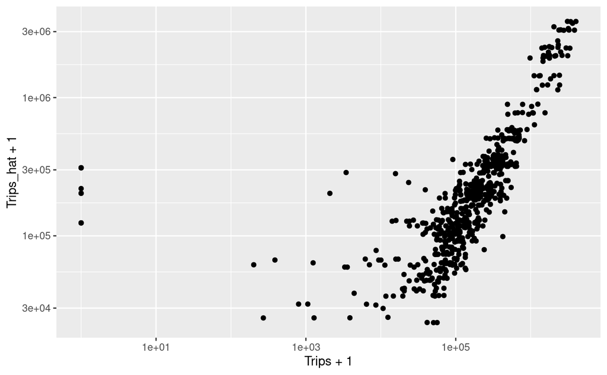

```r
private_trips_predictions_new %>%
  ggplot(aes(Trips+1, Trips_hat+1), ) +
  geom_point() +
  scale_x_log10() + scale_y_log10()
```

This is something of an improvement, though certainly not as good as I had hoped…

Have the main conclusions changed regarding the inverse-U shape?

```r
nd=data.frame(State="Florida",Month="06",
              Population=with(tripsTMPS,Population[State=="Florida" & Month=="01" & Mode==7 & Year==2020]),
              Stringency=seq(0,3000,by=50))

#Predicted trips as a function of stringency, including confidence intervals
pd=add_ci(nd,pm_new)

plot(y=pd$pred/1000000,x=pd$Stringency,type="l",ylim=c(2,5),xlim=c(3000,0),
     main="Private Boats",
     xlab="Stringency Index (Monthly sum of daily records: higher is more stringent)",
     ylab="Millions of Fishing Trips (Scaled to June 2020 in FL)")
lines(y=pd$LCB0.025/1000000,x=pd$Stringency,lty=2)
```

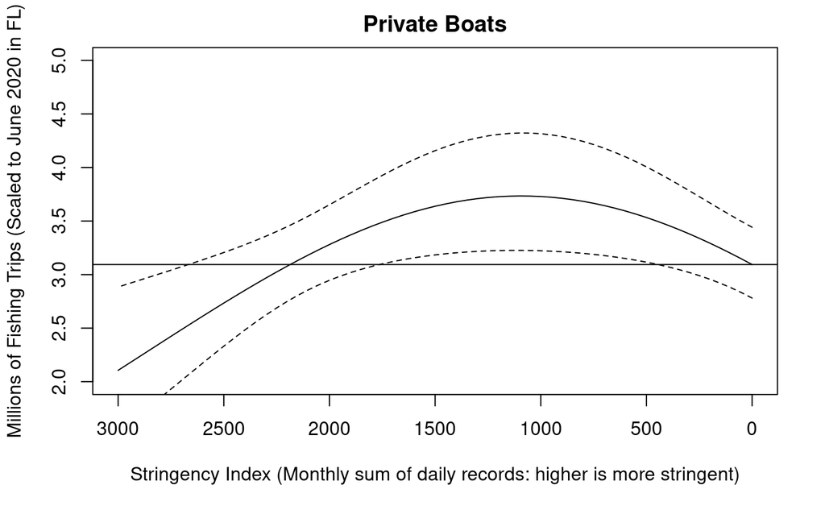

```r
lines(y=pd$UCB0.975/1000000,x=pd$Stringency,lty=2)
abline(h=pd$pred[pd$Stringency==0]/1000000)
```

They absolutely have not! And if anything, the confidence intervals are tighter since the model fit is improved, and so I think this is an improvement in every way. What is particularly striking to me is that the “break-even” point for stringency is essentially unchanged, around 2200.

What was I originally trying to do here? I seem to have gotten a bit side-tracked…

The original idea was to try and create counter-factual comparisons of how many total trips would have occurred in each state in 2020 if there had been no COVID. This is accomplished by taking predictions of each state-month given Stringency equal to 0.

First lets get the annual total under the actual scenario:

```r
tripsTMPS %>%
  filter(Mode == "7", Year == 2020) %>%
  group_by(State) %>%
  summarise(annual_trips = sum(Trips)) %>%
  arrange(annual_trips)
```

| State | annual_trips |
| --- | --- |
| New Hampshire | 242976.3 |
| Maine | 494090.1 |
| Delaware | 510674.6 |
| Rhode Island | 626252.3 |
| Connecticut | 1286887.4 |
| Mississippi | 1324740.3 |
| Georgia | 1584792.0 |
| Alabama | 1710506.5 |
| South Carolina | 2208456.6 |
| Massachusetts | 2219609.5 |

[output cut: 6 more lines]

It really is striking by what a large margin Florida has the most private boat fishing trips of any state…

Now, to get the predicted values for each state-month, we need to create a dataframe to which we can add the predictions:

```r
counterfactual_2020_w_no_COVID <- tripsTMPS %>%
  filter(Mode == "7", Year == 2020) %>%
  select(State, Month, Population) %>%
  mutate(Stringency = 0) %>%
  anti_join(no_data_sms, by = c("State", "Month"))

counterfactual_2020_w_no_COVID
```

| State | Month | Population | Stringency |
| --- | --- | --- | --- |
| Alabama | 01 | 5024279 | 0 |
| Florida | 01 | 21538187 | 0 |
| Mississippi | 01 | 2961279 | 0 |
| North Carolina | 01 | 10439388 | 0 |
| Alabama | 02 | 5024279 | 0 |
| Florida | 02 | 21538187 | 0 |
| Mississippi | 02 | 2961279 | 0 |
| North Carolina | 02 | 10439388 | 0 |
| Alabama | 03 | 5024279 | 0 |
| Connecticut | 03 | 3605944 | 0 |

[output cut: 147 more lines]

Note that I have excluded the 0 state-months, so that I can go back in and fill those with 0’s.

Now to add the predictions:

```r
counterfactual_2020_w_no_COVID <- counterfactual_2020_w_no_COVID %>%
  add_ci(pm_new)

counterfactual_2020_w_no_COVID
```

| State | Month | Population | Stringency | pred | LCB0.025 | UCB0.975 |
| --- | --- | --- | --- | --- | --- | --- |
| Alabama | 01 | 5024279 | 0 | 93507.21 | 73090.85 | 119626.44 |
| Florida | 01 | 21538187 | 0 | 1441629.58 | 1214880.56 | 1710699.73 |
| Mississippi | 01 | 2961279 | 0 | 73458.33 | 57073.01 | 94547.77 |
| North Carolina | 01 | 10439388 | 0 | 236325.93 | 194458.55 | 287207.46 |
| Alabama | 02 | 5024279 | 0 | 130462.26 | 103581.41 | 164319.08 |
| Florida | 02 | 21538187 | 0 | 2011376.99 | 1737462.12 | 2328475.17 |
| Mississippi | 02 | 2961279 | 0 | 102489.84 | 80939.76 | 129777.61 |
| North Carolina | 02 | 10439388 | 0 | 329724.46 | 277236.96 | 392149.10 |
| Alabama | 03 | 5024279 | 0 | 80113.58 | 63206.37 | 101543.34 |
| Connecticut | 03 | 3605944 | 0 | 66888.27 | 52280.60 | 85577.44 |

[output cut: 147 more lines]

And fill in the 0’s:

```r
counterfactual_2020_w_no_COVID <- counterfactual_2020_w_no_COVID %>%
  complete(State, Month) %>%
  mutate(Stringency = 0) %>%
  group_by(State) %>%
  fill(Population, .direction = "updown") %>%
  ungroup() %>%
  rename(Trips_hat = pred) %>%
  mutate(Trips_hat = if_else(is.na(Trips_hat), 0, Trips_hat))

counterfactual_2020_w_no_COVID
```

| State | Month | Population | Stringency | Trips_hat | LCB0.025 | UCB0.975 |
| --- | --- | --- | --- | --- | --- | --- |
| Alabama | 01 | 5024279 | 0 | 93507.21 | 73090.85 | 119626.44 |
| Alabama | 02 | 5024279 | 0 | 130462.26 | 103581.41 | 164319.08 |
| Alabama | 03 | 5024279 | 0 | 80113.58 | 63206.37 | 101543.34 |
| Alabama | 04 | 5024279 | 0 | 131262.79 | 105436.29 | 163415.47 |
| Alabama | 05 | 5024279 | 0 | 148282.91 | 119533.00 | 183947.70 |
| Alabama | 06 | 5024279 | 0 | 200665.12 | 162759.32 | 247399.00 |
| Alabama | 07 | 5024279 | 0 | 230847.87 | 187684.64 | 283937.68 |
| Alabama | 08 | 5024279 | 0 | 199789.56 | 162000.45 | 246393.57 |
| Alabama | 09 | 5024279 | 0 | 149869.90 | 120799.77 | 185935.69 |
| Alabama | 10 | 5024279 | 0 | 129748.59 | 104216.89 | 161535.20 |

[output cut: 182 more lines]

Now lets compare actual trips in 2020 with the predicted trips if there had been no COVID in 2020:

```r
annual_trips_2020_actual <- tripsTMPS %>%
  filter(Mode == "7", Year == 2020) %>%
  group_by(State) %>%
  summarise(annual_trips = sum(Trips)) %>%
  arrange(annual_trips)

annual_trips_2020_simulated_no_covid <- counterfactual_2020_w_no_COVID %>%
  group_by(State) %>%
  summarise(annual_trips_hat_no_covid = sum(Trips_hat))

annual_trips_2020_actual %>%
  left_join(annual_trips_2020_simulated_no_covid, by = "State") %>%
  mutate(percentage_increase_due_to_covid = 100 * (annual_trips - annual_trips_hat_no_covid) / annual_trips) %>%
  arrange(percentage_increase_due_to_covid)
```

| State | annual_trips | annual_trips_hat_no_covid | percentage_increase_due_to_covid |
| --- | --- | --- | --- |
| New Hampshire | 242976.3 | 262446.8 | -8.0133471 |
| Massachusetts | 2219609.5 | 2334072.1 | -5.1568842 |
| New York | 5464054.4 | 5725689.2 | -4.7882923 |
| South Carolina | 2208456.6 | 2225567.4 | -0.7747847 |
| Mississippi | 1324740.3 | 1330982.0 | -0.4711584 |
| Alabama | 1710506.5 | 1694245.1 | 0.9506777 |
| Maine | 494090.1 | 486044.0 | 1.6284838 |
| Florida | 27272473.8 | 26120700.6 | 4.2232078 |
| Connecticut | 1286887.4 | 1227559.6 | 4.6101831 |
| Georgia | 1584792.0 | 1461135.9 | 7.8026700 |

[output cut: 6 more lines]

Here we see most states had more trips than the model predicts they would have without COVID

I would like to look at the relationship between these percentage changes and the trip-weighted average of the COVID stringency index for each state. My hypothesis is that the states with higher average stringency are the ones that saw decreases in trips.

```r
twas <- tripsTMPS %>%
  filter(Year == 2020, Mode == "7") %>%
  group_by(State) %>%
  summarise(trip_weighted_average_stringency = weighted.mean(Stringency, Trips)) %>%
  arrange(trip_weighted_average_stringency)

twas
```

| State | trip_weighted_average_stringency |
| --- | --- |
| Alabama | 1449.103 |
| Mississippi | 1557.311 |
| New Hampshire | 1592.670 |
| Florida | 1616.642 |
| South Carolina | 1722.300 |
| Virginia | 1827.885 |
| North Carolina | 1835.157 |
| Georgia | 1894.029 |
| Maryland | 1915.115 |
| Massachusetts | 1938.537 |

[output cut: 6 more lines]

```r
annual_trips_2020_actual %>%
  left_join(annual_trips_2020_simulated_no_covid, by = "State") %>%
  mutate(percentage_increase_due_to_covid = 100 * (annual_trips - annual_trips_hat_no_covid) / annual_trips) %>%
  left_join(twas, by = "State")
```

| State | annual_trips | annual_trips_hat_no_covid | percentage_increase_due_to_covid | trip_weighted_average_stringency |
| --- | --- | --- | --- | --- |
| New Hampshire | 242976.3 | 262446.8 | -8.0133471 | 1592.670 |
| Maine | 494090.1 | 486044.0 | 1.6284838 | 2441.420 |
| Delaware | 510674.6 | 469580.9 | 8.0469426 | 2059.103 |
| Rhode Island | 626252.3 | 547999.3 | 12.4954426 | 2137.916 |
| Connecticut | 1286887.4 | 1227559.6 | 4.6101831 | 2111.966 |
| Mississippi | 1324740.3 | 1330982.0 | -0.4711584 | 1557.311 |
| Georgia | 1584792.0 | 1461135.9 | 7.8026700 | 1894.029 |
| Alabama | 1710506.5 | 1694245.1 | 0.9506777 | 1449.103 |
| South Carolina | 2208456.6 | 2225567.4 | -0.7747847 | 1722.300 |
| Massachusetts | 2219609.5 | 2334072.1 | -5.1568842 | 1938.537 |

[output cut: 6 more lines]

Plot:

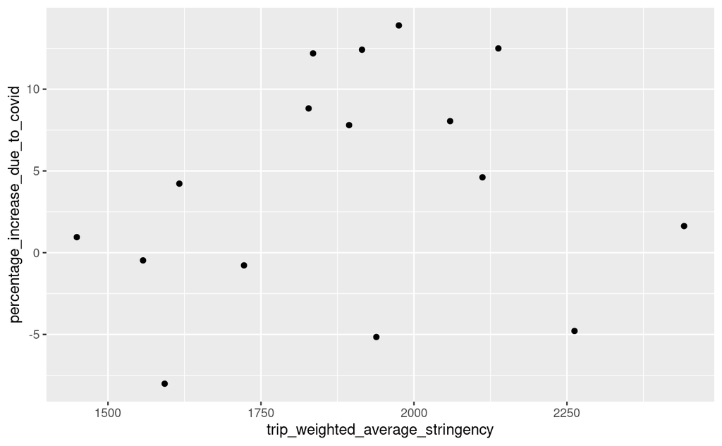

```r
annual_trips_2020_actual %>%
  left_join(annual_trips_2020_simulated_no_covid, by = "State") %>%
  mutate(percentage_increase_due_to_covid = 100 * (annual_trips - annual_trips_hat_no_covid) / annual_trips) %>%
  left_join(twas, by = "State") %>%
  ggplot(aes(x = trip_weighted_average_stringency, y = percentage_increase_due_to_covid)) +
  geom_point()
```

How about a correlation:

```r
comparison_2020_df <- annual_trips_2020_actual %>%
  left_join(annual_trips_2020_simulated_no_covid, by = "State") %>%
  mutate(percentage_increase_due_to_covid = 100 * (annual_trips - annual_trips_hat_no_covid) / annual_trips) %>%
  left_join(twas, by = "State")

cor(comparison_2020_df$percentage_increase_due_to_covid, comparison_2020_df$trip_weighted_average_stringency)
```

```
[1] 0.1897143
```

```r
counterfactual_2019_w_COVID <- tripsTMPS %>%
  filter(Mode == "7", Year == 2019) %>%
  select(State, Month, Population) %>%
  anti_join(no_data_sms, by = c("State", "Month"))

counterfactual_2019_w_COVID
```

| State | Month | Population |
| --- | --- | --- |
| Alabama | 01 | 4903185 |
| Florida | 01 | 21477737 |
| Mississippi | 01 | 2976149 |
| North Carolina | 01 | 10488084 |
| Alabama | 02 | 4903185 |
| Florida | 02 | 21477737 |
| Mississippi | 02 | 2976149 |
| North Carolina | 02 | 10488084 |
| Alabama | 03 | 4903185 |
| Connecticut | 03 | 3565287 |

[output cut: 147 more lines]

We now want to join the 2020 Stringency values:

```r
counterfactual_2019_w_COVID <- tripsTMPS %>%
  filter(Mode == "7", Year == 2020) %>%
  select(State, Month, Stringency) %>%
  right_join(counterfactual_2019_w_COVID, by = c("State", "Month"))

counterfactual_2019_w_COVID
```

| State | Month | Stringency | Population |
| --- | --- | --- | --- |
| Alabama | 01 | 0.00 | 4903185 |
| Florida | 01 | 0.00 | 21477737 |
| Mississippi | 01 | 0.00 | 2976149 |
| North Carolina | 01 | 0.00 | 10488084 |
| Alabama | 02 | 155.68 | 4903185 |
| Florida | 02 | 183.43 | 21477737 |
| Mississippi | 02 | 155.68 | 2976149 |
| North Carolina | 02 | 155.68 | 10488084 |
| Alabama | 03 | 1201.36 | 4903185 |
| Connecticut | 03 | 1525.42 | 3565287 |

[output cut: 147 more lines]

Now we can add in the predictions from the model, and then fill the 0’s:

```r
counterfactual_2019_w_COVID <- counterfactual_2019_w_COVID %>%
  add_ci(pm_new) %>%
  complete(State, Month) %>%
  rename(Trips_hat = pred) %>%
  mutate(Trips_hat = if_else(is.na(Trips_hat), 0, Trips_hat))

counterfactual_2019_w_COVID
```

| State | Month | Stringency | Population | Trips_hat | LCB0.025 | UCB0.975 |
| --- | --- | --- | --- | --- | --- | --- |
| Alabama | 01 | 0.00 | 4903185 | 93125.67 | 73558.84 | 117897.32 |
| Alabama | 02 | 155.68 | 4903185 | 136561.54 | 109755.31 | 169914.81 |
| Alabama | 03 | 1201.36 | 4903185 | 96126.54 | 75969.12 | 121632.47 |
| Alabama | 04 | 2366.21 | 4903185 | 122241.76 | 97182.22 | 153763.20 |
| Alabama | 05 | 2070.31 | 4903185 | 153360.10 | 123870.38 | 189870.42 |
| Alabama | 06 | 1560.15 | 4903185 | 233071.56 | 188300.59 | 288487.43 |
| Alabama | 07 | 1550.00 | 4903185 | 268525.00 | 217238.36 | 331919.64 |
| Alabama | 08 | 1494.48 | 4903185 | 234148.34 | 189255.56 | 289690.02 |
| Alabama | 09 | 1318.55 | 4903185 | 178721.24 | 143708.56 | 222264.30 |
| Alabama | 10 | 1349.12 | 4903185 | 154368.09 | 123976.82 | 192209.38 |

[output cut: 182 more lines]

Now to get the actual 2019 values for comparison:

```r
annual_trips_2019_actual <- tripsTMPS %>%
  filter(Mode == "7", Year == 2019) %>%
  group_by(State) %>%
  summarise(annual_trips = sum(Trips)) %>%
  arrange(annual_trips)

annual_trips_2019_simulated_w_covid <- counterfactual_2019_w_COVID %>%
  group_by(State) %>%
  summarise(annual_trips_hat_w_covid = sum(Trips_hat))

annual_trips_2019_actual %>%
  left_join(annual_trips_2019_simulated_w_covid, by = "State") %>%
  mutate(percentage_increase_if_covid = 100 * (annual_trips_hat_w_covid - annual_trips) / annual_trips) %>%
  arrange(percentage_increase_if_covid)
```

| State | annual_trips | annual_trips_hat_w_covid | percentage_increase_if_covid |
| --- | --- | --- | --- |
| Rhode Island | 605406.5 | 549594.4 | -9.2189418 |
| Maine | 465615.5 | 432851.9 | -7.0366176 |
| Virginia | 2396552.5 | 2282725.4 | -4.7496174 |
| New York | 5716402.0 | 5520708.5 | -3.4233674 |
| Connecticut | 1290106.1 | 1253202.3 | -2.8605297 |
| South Carolina | 2471348.7 | 2483285.2 | 0.4829976 |
| North Carolina | 4201672.9 | 4492089.2 | 6.9119212 |
| Maryland | 2205730.1 | 2431535.0 | 10.2371967 |
| Massachusetts | 2202492.0 | 2468471.8 | 12.0763104 |
| Mississippi | 1273282.3 | 1448541.9 | 13.7644017 |

[output cut: 6 more lines]

The rankings of states do not seem to be especially preserved in any way…

Lets look at a scatter plot of the 2 percentage changes I have calculated:

```r
counterfactuals_2019 <- annual_trips_2019_actual %>%
  left_join(annual_trips_2019_simulated_w_covid, by = "State") %>%
  mutate(percentage_increase_if_covid = 100 * (annual_trips_hat_w_covid - annual_trips) / annual_trips) %>%
  arrange(percentage_increase_if_covid) %>%
  rename(annual_trips_2019 = annual_trips,
         annual_trips_2019_hat_w_covid = annual_trips_hat_w_covid,
         percentage_increase_2019_if_covid = percentage_increase_if_covid)

counterfactuals_2020 <- annual_trips_2020_actual %>%
  left_join(annual_trips_2020_simulated_no_covid, by = "State") %>%
  mutate(percentage_increase_due_to_covid = 100 * (annual_trips - annual_trips_hat_no_covid) / annual_trips) %>%
  arrange(percentage_increase_due_to_covid) %>%
  rename(annual_trips_2020 = annual_trips,
         annual_trips_2020_hat_no_covid = annual_trips_hat_no_covid,
         percentage_increase_2020_due_to_covid = percentage_increase_due_to_covid)

counterfactuals <- counterfactuals_2019 %>%
  left_join(counterfactuals_2020, by = "State")

counterfactuals
```

| State | annual_trips_2019 | annual_trips_2019_hat_w_covid | percentage_increase_2019_if_covid | annual_trips_2020 | annual_trips_2020_hat_no_covid | percentage_increase_2020_due_to_covid |
| --- | --- | --- | --- | --- | --- | --- |
| Rhode Island | 605406.5 | 549594.4 | -9.2189418 | 626252.3 | 547999.3 | 12.4954426 |
| Maine | 465615.5 | 432851.9 | -7.0366176 | 494090.1 | 486044.0 | 1.6284838 |
| Virginia | 2396552.5 | 2282725.4 | -4.7496174 | 2304978.3 | 2101594.3 | 8.8236845 |
| New York | 5716402.0 | 5520708.5 | -3.4233674 | 5464054.4 | 5725689.2 | -4.7882923 |
| Connecticut | 1290106.1 | 1253202.3 | -2.8605297 | 1286887.4 | 1227559.6 | 4.6101831 |
| South Carolina | 2471348.7 | 2483285.2 | 0.4829976 | 2208456.6 | 2225567.4 | -0.7747847 |
| North Carolina | 4201672.9 | 4492089.2 | 6.9119212 | 4876412.7 | 4281959.1 | 12.1903879 |
| Maryland | 2205730.1 | 2431535.0 | 10.2371967 | 2681515.4 | 2348633.0 | 12.4139633 |
| Massachusetts | 2202492.0 | 2468471.8 | 12.0763104 | 2219609.5 | 2334072.1 | -5.1568842 |
| Mississippi | 1273282.3 | 1448541.9 | 13.7644017 | 1324740.3 | 1330982.0 | -0.4711584 |

[output cut: 6 more lines]

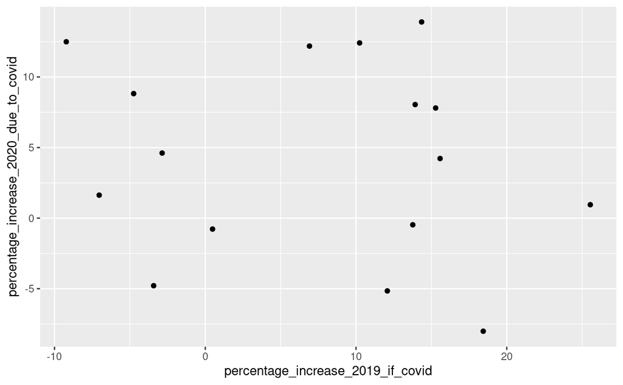

```r
counterfactuals %>%
  ggplot(aes(x = percentage_increase_2019_if_covid, y = percentage_increase_2020_due_to_covid)) +
  geom_point()
```

and a correlation coefficient:

```r
cor(counterfactuals$percentage_increase_2019_if_covid,
    counterfactuals$percentage_increase_2020_due_to_covid)
```

```
[1] -0.1431107
```

And this somehow manages to be negative, which does not make sense to me… I don’t think it is worth pursuing this route any further.